# Results in Uto et al paper

Here we reproduce the model in Uto et al. using nimble.

I will use the notation in the paper.

Consider $N$ examinees who are independently assessed on multiple $I$ items by multiple $R$ raters. Each examinee is rated by a subset of raters $\mathcal{R}_j$, with cardinality $|\mathcal{R}_j|\leq R$, on the same set of items $i=1,\dots, I$. We let $\mathcal{J}_r = \{ j: r \in \mathcal{R}_j\}$ be the set of subjects scored by rater $r=1,\dots, R$. Let $Y_{jir}$ for $j=1,\dots,J$, $r \in \mathcal{R}_j$ and $i=1,\dots,I$ be a categorical random variable recording the examinee $j$’s score given by rater $r$ to item $i$. We consider, without loss of generality, that $Y_{jir} \in \{0, 1, \ldots, K\}$, for $i=1.\dots, I$, that is, all items comprise the same range of ordered categorical values. We further assume that the items measure a unidimensional construct modelled by a subject-specific latent trait $\theta_j \in \mathbb{R}$.

The model in Uto et al has the following form:

$$\begin{equation}
\mathbb{P}[Y_{jir}=k|Y_{jir} \in \{k,k-1\},\theta_j, \phi_{ir}, \delta_{irk}]=
\frac{exp\{D* \phi_{ir}(\theta_j - \delta_{irk})\}}{1+exp\{D* \phi_{ir}(\theta_j - \delta_{irk})\}}
\end{equation}$$

for $k=1,\dots, K;$ $j=1,\dots, N;$ $i=1,\dots, I$ and $r \in \mathcal{R}_j$.

The scale term is decomposed as
$$\begin{equation}
\phi_{ir} = \alpha_{i} \alpha_{r}
\end{equation}$$
where $\alpha_{i}$ represents the discriminatory power of item $i$, $\alpha_{r}$ represents the consistency of rater $r$.

In the location part, the novely is that the model considers a rater–item interaction parameter representing the rater severity for valuation item ($\beta_{ir}$) and an item-specific step-difficulty parameter representing the difference in rating scales among evaluation items ($d_{rm}$).

$$\begin{equation}
\delta_{irk} = \beta_{ir} + d_{im} + d_{rm}
\end{equation}$$

**Note**: In the paper the term in the exponential is multiplied by $D = 1.7$ which is the scaling constant used to minimize the difference between the normal and logistic distribution functions.

### Constraints

Scale. $\sum_{r = 1}^R \log \alpha_r = 0$

Location.

- $d_{r1} = 0$; $\sum_{k = 2}^K d_{rk} = 0$
- $d_{i1} = 0$; $\sum_{k = 2}^K d_{ik} = 0$

### Results

**Estimates fron nimble**

```r
alpha_r <- samples[, grep("^trans_alpha_r", colnames(samples))] |> colMeans()

## apply constraints on the posterior means for the scaling
get_prod_restricted_prm <- function(d){
  return(append(1.0/prod(d), d))
}
alpha_r<- get_prod_restricted_prm(alpha_r[2:5])


#######
d_rk <- samples[, grep("^category_est_r", colnames(samples))] |> colMeans() |> matrix(nrow = 5)

beta_ir <- samples[, grep("^beta_ir", colnames(samples))] |> colMeans()

severity <- beta_ir |> matrix(nrow = 30, byrow = FALSE) |> colMeans()


tab <- data.frame("alpha_r" = alpha_r,
                  "d_{r1}" = d_rk[, 1],
                  "d_{r2}" = d_rk[, 2],
                  "d_{r3}" = d_rk[, 3],
                  "d_{r4}" = d_rk[, 4],
                  "severity" = severity,
                  row.names = NULL)

knitr::kable(tab, col.names = c("$\\alpha_r$", "$d_{r1}$",
                                "$d_{r2}$", "$d_{r3}$",
                                "$d_{r4}$", "severity"))
```

| $\alpha_r$ | $d_{r1}$ | $d_{r2}$ | $d_{r3}$ | $d_{r4}$ | severity |
| --- | --- | --- | --- | --- | --- |
| 0.9734014 | 0 | -0.5818935 | -1.8708880 | 2.452781 | 0.1576033 |
| 0.8441388 | 0 | -1.1948299 | -1.4901946 | 2.685025 | 0.0956941 |
| 1.3150177 | 0 | -0.8091529 | -0.4118823 | 1.221035 | -0.1679036 |
| 1.0236239 | 0 | -0.8653008 | -0.8771412 | 1.742442 | -0.3023658 |
| 0.9041118 | 0 | -0.9593043 | -1.2668492 | 2.226154 | 0.1342729 |

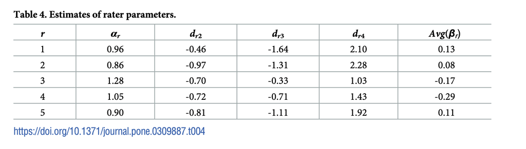

paper_results

Note: the difference is in that in the paper they apply the constraint on the posterior means; not sure if this is necessary.

**Posterior distribution of the latent trait (parametric model)**

Here I am looking at the distribution of all MCMC samples of the latent trait.

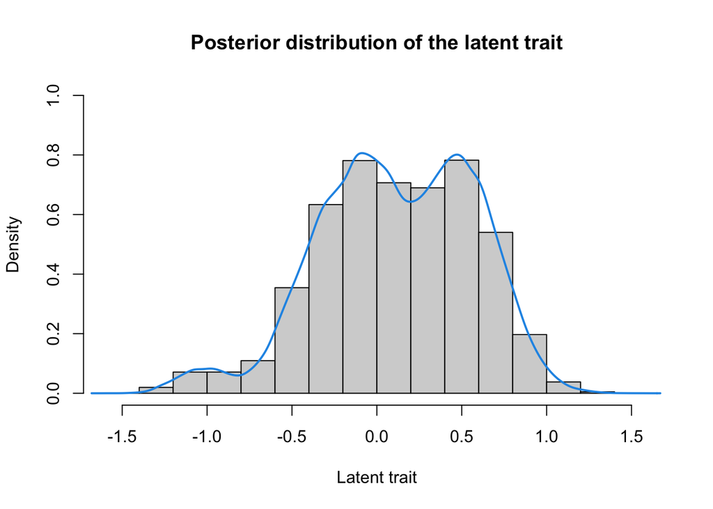

```r
hist(samples[, grep("^eta", colnames(samples))],
    breaks = 20, prob= TRUE, ylim = c(0,1),
    main = "Posterior distribution of the latent trait",
    xlab = "Latent trait")
lines(density(samples[, grep("^eta", colnames(samples))]), col = 4, lwd = 2)
```

```r
alpha_i <- samples[, grep("^alpha_i", colnames(samples))] |> colMeans()
```

### Semiparametric version

I removed the multiplication by 1.7. Using a DP mixture for the latent ability. Prior on DP concentration parameter is $Gamma(1,3)$ (expected number of clusters a priori is around 2 with variance 2). Also here it make sense to consider the variance for the cluster components; since there is not huge variability on the scores scale, I would consider a small variance.

**Estimates fron nimble**

```r
alpha_r <- samples[, grep("^trans_alpha_r", colnames(samples))] |> colMeans()

## apply constraints on the posterior means for the scaling
get_prod_restricted_prm <- function(d){
  return(append(1.0/prod(d), d))
}
alpha_r<- get_prod_restricted_prm(alpha_r[2:5])


#######
d_rk <- samples[, grep("^category_est_r", colnames(samples))] |> colMeans() |> matrix(nrow = 5)

beta_ir <- samples[, grep("^beta_ir", colnames(samples))] |> colMeans()

severity <- beta_ir |> matrix(nrow = 30, byrow = FALSE) |> colMeans()


tab <- data.frame("alpha_r" = alpha_r,
                  "d_{r1}" = d_rk[, 1],
                  "d_{r2}" = d_rk[, 2],
                  "d_{r3}" = d_rk[, 3],
                  "d_{r4}" = d_rk[, 4],
                  "severity" = severity,
                  row.names = NULL)

knitr::kable(tab, col.names = c("$\\alpha_r$", "$d_{r1}$",
                                "$d_{r2}$", "$d_{r3}$",
                                "$d_{r4}$", "severity"))
```

| $\alpha_r$ | $d_{r1}$ | $d_{r2}$ | $d_{r3}$ | $d_{r4}$ | severity |
| --- | --- | --- | --- | --- | --- |
| 0.9969892 | 0 | -0.6269979 | -1.7813076 | 2.408305 | 0.1809079 |
| 0.8386913 | 0 | -1.2380691 | -1.4348694 | 2.672938 | 0.1232906 |
| 1.2940692 | 0 | -0.8850919 | -0.3575986 | 1.242690 | -0.1741128 |
| 1.0085948 | 0 | -0.9022044 | -0.8244632 | 1.726668 | -0.2956169 |
| 0.9162905 | 0 | -0.9769934 | -1.2111875 | 2.188181 | 0.1470102 |

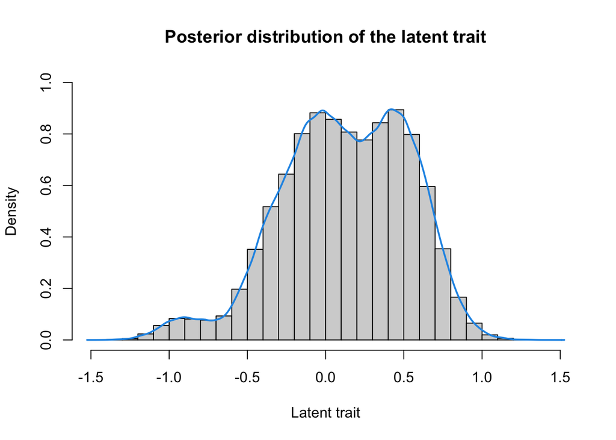

```r
source("functions/estimateDPdensity.R")

hist(samples[, grep("^eta", colnames(samples))],
    breaks = 25, prob= TRUE, ylim = c(0, 1),
    main = "Posterior distribution of the latent trait",
    xlab = "Latent trait")
lines(density(samples[, grep("^eta", colnames(samples))]), col = 4, lwd = 2)
```

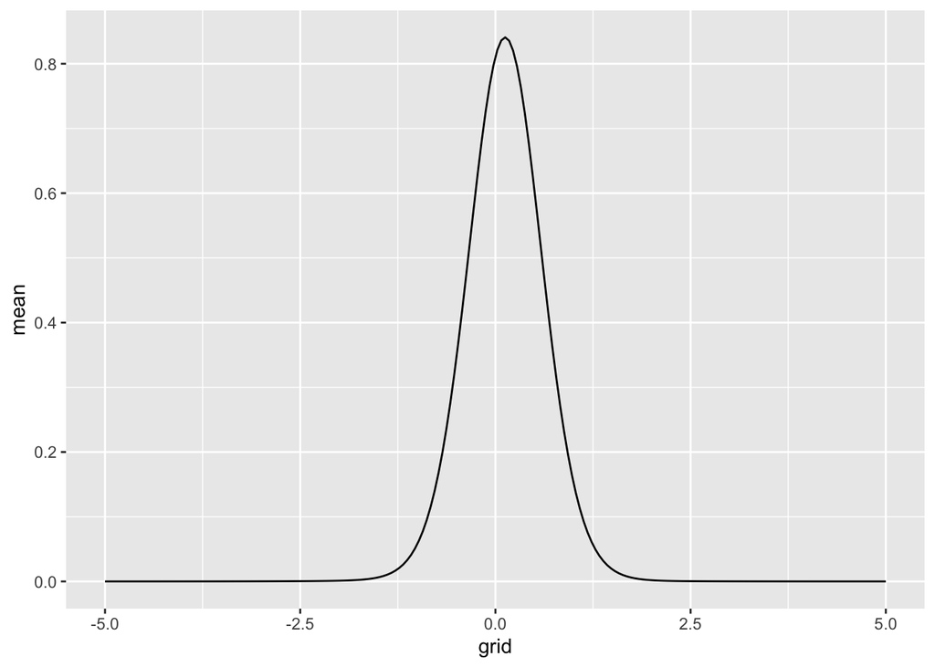

```r
out <- estimateDPdensity(samples,
                         paramNames = list(alpha = "alpha_dp",
                                          muTilde = "muTilde",
                                          s2Tilde = "s2Tilde",
                                          zi = "zi"),
                         nIndividuals = 30,
    grid = seq(-5, 5, length = 200))

res <- data.frame(grid = out$grid, mean = apply(out$densitySamples, 2, mean))

ggplot(data = res,
                aes(x = grid, y = mean)) +
  geom_line()
```

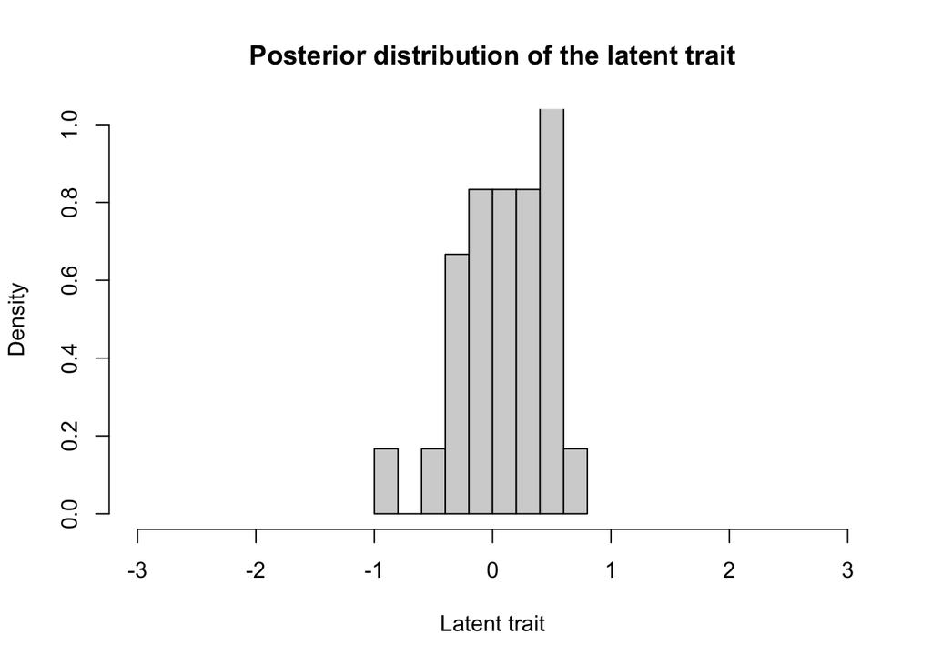

```r
hist(apply(samples[, grep("^eta", colnames(samples))], 2, mean),
     freq = FALSE, xlim = c(-3,3),
    breaks = 10, prob= TRUE, ylim = c(0,1),
    main = "Posterior distribution of the latent trait",
    xlab = "Latent trait")## pointwise estimate of the density for standardized log grid
```

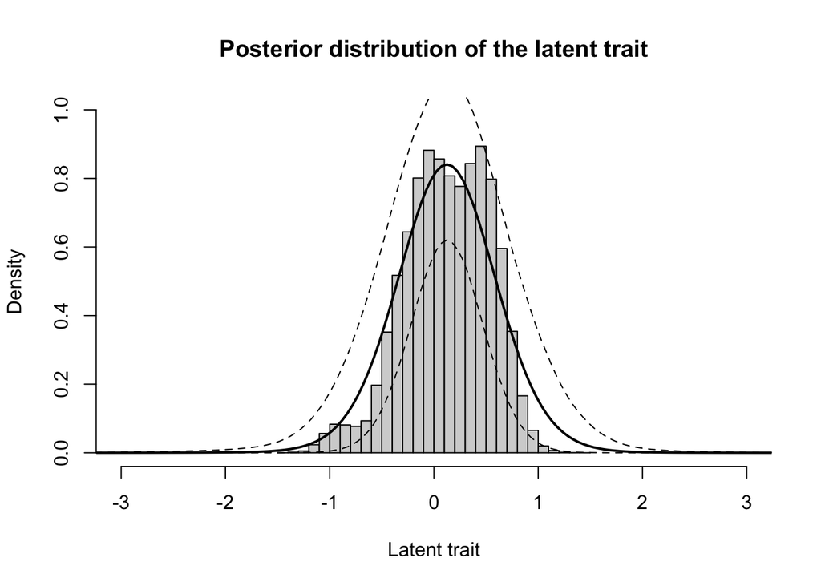

```r
hist(samples[, grep("^eta", colnames(samples))],
     freq = FALSE, xlim = c(-3,3),
    breaks = 30, prob= TRUE, ylim = c(0,1),
    main = "Posterior distribution of the latent trait",
    xlab = "Latent trait")## pointwise estimate of the density for standardized log grid
lines(out$grid, apply(out$densitySamples, 2, mean), lwd = 2, col = 'black')
lines(out$grid, apply(out$densitySamples, 2, quantile, 0.025), lty = 2, col = 'black')
lines(out$grid, apply(out$densitySamples, 2, quantile, 0.975), lty = 2, col = 'black')
```

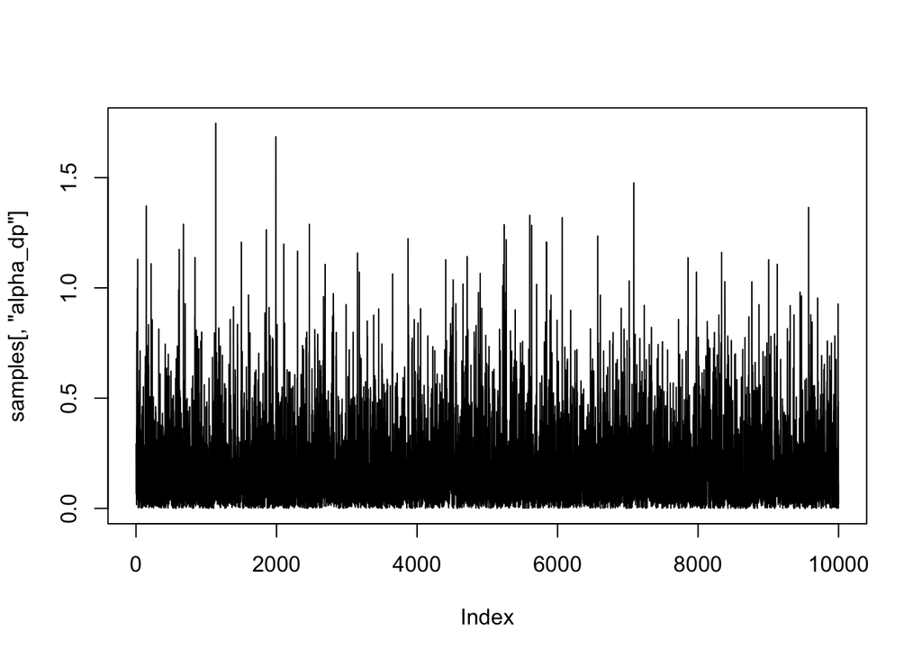

```r
plot(samples[, "alpha_dp"], type = "l")
```

```r
mean(samples[, "alpha_dp"])
```

```
[1] 0.1824272
```

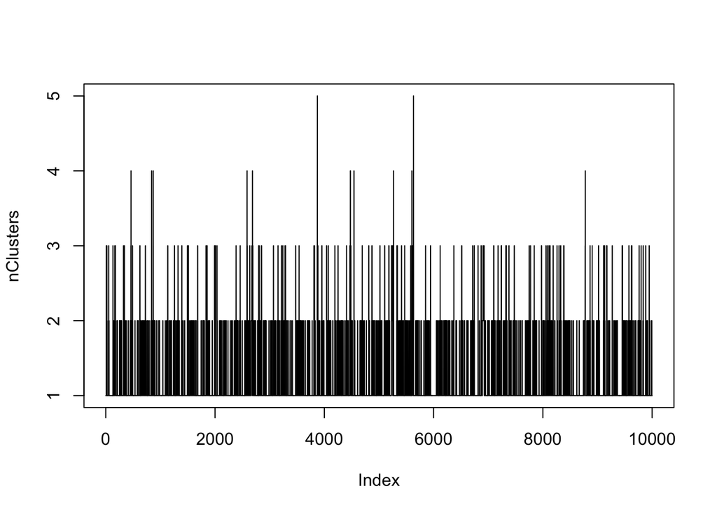

```r
nClusters <- apply(samples[, grep("zi", colnames(samples))], 1, \(x) length(unique(x)))

plot(nClusters, type = "l")
```

```r
library(salso)

cc <- salso(samples[, grep("zi", colnames(samples))])
cc
```

```
 [1] 1 1 1 1 1 1 1 1 1 1 1 1 1 1 1 1 1 1 1 1 1 1 1 1 1 1 1 1 1 1
attr(,"info")
 loss a maxNClusters expectedLoss initMethod nScans nZAcc nZAtt nRuns   seconds
   VI 1            5   0.06641545      empty      1     0     1    24 0.0109375
```

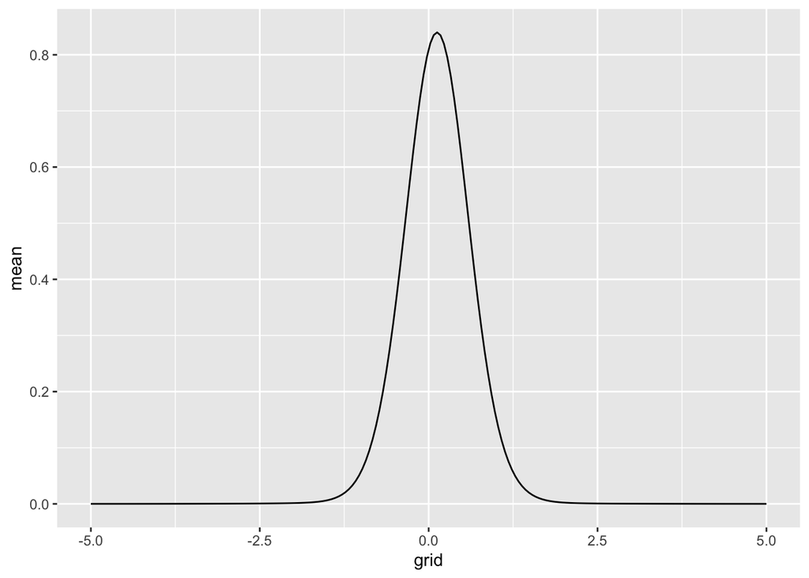

```r
densityDPMeasure <- matrix(0, ncol = length(out$grid), nrow = length(resObj$outputG))

for(i in seq_len(length(resObj$outputG))) {
    densityDPMeasure[i, ] <- sapply(out$grid,
                function(x)(
                  sum(resObj$outputG[[i]][,1]*
                    dnorm(x, resObj$outputG[[i]][,2], sqrt(resObj$outputG[[i]][,3])))))
}

res2 <- data.frame(grid = out$grid, mean = apply(densityDPMeasure, 2, mean))

ggplot(data = res2,aes(x = grid, y = mean)) +
  geom_line()
```